# Practical 5: Word Embeddings

### Instructor: Dr. Maryam Movahedifar

**Applied Text Mining - University of Bremen - Data Science Center**

[figure not shown]

```python
!rm -rf ~/.cache
```

# Installation

1. **Make sure you have `sklearn`, `matplotlib` and `numpy` installed.**

```python
!pip install --upgrade numpy matplotlib scikit-learn gensim
```

[output not shown]

```python
%matplotlib inline

import numpy as np
import matplotlib.pyplot as plt

from sklearn.decomposition import PCA
from numpy import linalg as LA

import gensim.downloader as api
from gensim.test.utils import datapath
```

# Using the `gensim` Library

In this practical session, we're going to use the **gensim** library. This library offers a variety of methods to read in pre-trained word embeddings as well as train your own.

The website contains a lot of documentation. For example, you can check out this link:  
https://radimrehurek.com/gensim/auto_examples/index.html#documentation

# Reading in a Pre-trained Model

First, we load in a pre-trained **GloVe** model.  
**Note:** this can take around five minutes.

See https://github.com/RaRe-Technologies/gensim-data for an overview of the models you can try. For example:

- `word2vec-google-news-300`: Word2Vec trained on Google News (1662 MB)
- `glove-twitter-200`: GloVe trained on Twitter data (758 MB)

We're going to start with:

- `glove-wiki-gigaword-300` (376.1 MB)  
  These embeddings are trained on Wikipedia (2014) and the Gigaword corpus, a large collection of newswire text.

```python
wv = api.load('glove-wiki-gigaword-300')
```

# Exploring the Vocabulary

How many words does the vocabulary contain?

```python
len(wv)
```

```
400000
```

Is `'bremen'` in the vocabulary?

```python
'bremen' in wv
```

```
True
```

Print a word embedding.

```python
wv["bremen"]
```

```
array([ 0.22526  ,  0.43879  , -0.36044  ,  0.50857  ,  1.1895   ,
       -0.47383  , -0.4365   , -0.67327  ,  0.73142  , -0.099612 ,
       -0.27479  ,  0.3085   , -0.26265  , -0.24295  ,  0.5761   ,
        0.57053  , -0.35053  ,  0.22753  ,  0.41131  , -0.036253 ,
        0.66832  ,  0.14124  , -0.39362  , -0.15254  , -0.36964  ,
       -0.11615  , -0.095743 ,  0.76582  , -0.392    ,  0.15877  ,
        0.23427  , -0.11292  , -0.14845  ,  0.28933  , -0.51626  ,
       -0.84905  ,  0.49341  ,  0.079582 , -0.028299 ,  0.26135  ,
       -0.22216  , -0.42376  , -1.2625   , -0.71171  , -0.35453  ,
       -0.08217  ,  0.47379  ,  0.3912   ,  0.29368  , -0.19623  ,
        0.17192  ,  0.13207  , -0.4069   , -0.14299  ,  0.23173  ,
        0.1209   , -0.28619  , -0.56747  , -0.30584  ,  0.58731  ,
       -0.55136  , -0.32079  , -0.095754 , -0.24142  ,  0.093503 ,
       -0.032664 ,  0.088266 , -0.45845  , -0.11977  , -0.87934  ,
       -0.078749 ,  0.78534  ,  0.071001 ,  0.15955  , -0.4901   ,
       -0.015808 , -0.42538  ,  0.6218   , -0.37392  , -0.0061261,
        0.08188  ,  0.66601  , -0.18662  ,  0.064982 , -0.25074  ,
        0.60001  , -0.48618  ,  0.40454  ,  0.11624  ,  0.28171  ,
        0.30429  , -0.21392  ,  0.4512   , -0.87715  , -0.06343  ,
        0.031764 ,  0.16688  ,  0.56263  , -0.10182  , -0.067443 ,
       -0.42168  , -0.30312  ,  0.39989  , -0.39218  ,  0.10445  ,
       -0.35321  ,  0.39143  , -0.0019161, -0.22576  ,  0.46738  ,
        0.4992   , -0.070753 , -0.14582  , -0.22491  , -0.24731  ,
        0.1821   , -0.48298  ,  0.15924  ,  0.36172  ,  0.040559 ,
       -0.2107   , -0.275    ,  0.9956   ,  0.40572  ,  0.035424 ,
        0.095525 , -0.24909  , -0.49376  , -0.3901   ,  0.14896  ,
        0.34858  ,  0.53836  , -0.5964   ,  0.52087  , -0.10588  ,
       -0.28097  ,  0.33003  , -0.057186 , -0.084591 ,  0.17129  ,
        0.11568  ,  0.062952 ,  0.21245  , -0.2707   ,  0.70873  ,
        0.94142  , -0.016878 ,  0.1052   , -0.44558  ,  0.041047 ,
        0.011303 ,  0.1331   ,  0.16032  , -0.11049  ,  0.079258 ,
        0.89359  ,  0.30666  , -0.39109  , -0.35342  ,  0.35945  ,
       -0.0050702, -0.061621 ,  0.24515  , -0.57911  ,  0.29852  ,
        0.19136  ,  0.58645  , -0.62272  ,  0.56947  , -0.061661 ,
        0.15696  , -0.68424  , -0.41801  , -0.081603 ,  0.48348  ,
       -0.12058  ,  0.46678  ,  0.26274  ,  0.0025052,  0.94692  ,
        0.26124  ,  0.085942 , -0.83092  , -0.65956  ,  0.47163  ,
        0.012313 , -0.83716  , -0.36749  ,  0.57754  ,  0.17746  ,
        0.12566  , -0.085005 ,  0.034362 ,  0.2569   ,  0.16457  ,
       -0.11307  , -0.27002  , -0.49347  , -0.34287  ,  0.28402  ,
        0.57792  , -0.14389  , -0.13455  , -0.59051  , -0.1189   ,
       -1.2794   ,  0.036593 , -0.45598  , -0.58268  ,  0.034894 ,
       -0.17615  , -0.007303 , -0.52767  , -0.10986  ,  0.20272  ,
       -0.038567 ,  0.12016  ,  0.46693  , -0.88641  , -0.37798  ,
        0.26959  , -0.49073  ,  0.04989  ,  0.35725  , -0.85089  ,
       -0.094032 ,  0.047829 , -1.0477   ,  0.027935 ,  0.05842  ,
       -0.40369  ,  0.54261  ,  0.96349  ,  0.0089743,  0.42196  ,
       -0.20431  , -0.10447  ,  0.24232  ,  0.19164  ,  0.52376  ,
       -0.21517  , -0.5462   , -0.24218  ,  0.049104 ,  0.35552  ,
        0.87659  ,  0.48834  ,  0.90783  ,  0.060131 , -0.15595  ,
       -0.29257  ,  0.0096559,  0.20742  ,  0.69767  , -0.14198  ,
        0.045843 ,  0.33252  , -0.90428  , -0.12376  ,  0.41046  ,
       -0.14977  ,  0.21895  ,  0.45372  ,  0.38178  , -0.25503  ,
        0.33104  , -0.37355  , -0.54882  ,  0.37023  , -0.3059   ,
        0.76358  ,  0.29846  , -0.36981  ,  0.39099  ,  0.20005  ,
       -0.16363  ,  0.056834 , -0.4424   , -0.25852  ,  0.62705  ,
       -0.99437  ,  0.60539  , -0.71551  ,  0.077816 ,  0.15008  ,
       -0.08974  , -0.22994  ,  0.1931   ,  0.29954  , -0.20674  ,
       -0.086557 , -0.20419  ,  0.24908  , -0.66591  ,  0.32684  ,
       -0.17528  ,  0.2413   , -0.58363  ,  0.33629  ,  0.14946  ],
      dtype=float32)
```

How many dimensions does this embedding have?

```python
wv["bremen"].shape
```

```
(300,)
```

**Question:** Explore the embeddings for a few other words.  
Can you find words that are *not* in the vocabulary?

*(For example, think of uncommon words, misspellings, new words, etc.)*

# Vector Arithmetic

We can calculate the [**cosine similarity**](https://en.wikipedia.org/wiki/Cosine_similarity) between two words in this way:

```python
wv.similarity('university', 'student')
```

```
0.5970513
```

Optional: cosine similarity is the same as the dot product between the normalized word embeddings

```python
wv_university_norm = wv['university']/ LA.norm(wv['university'], 2)
wv_student_norm = wv['student'] / LA.norm(wv['student'], 2)

wv_university_norm.dot(wv_student_norm)
```

```
0.5970514
```

A normalized embedding has a L2 norm (length) of 1

```python
LA.norm(wv_student_norm)
```

```
1.0
```

# Similarity Analysis

Print the top 5 most similar words to **car**

```python
print(wv.most_similar(positive=['car'], topn=5))
```

```
[('cars', 0.7827162146568298), ('vehicle', 0.7655367851257324), ('truck', 0.7350621819496155), ('driver', 0.7114784717559814), ('driving', 0.6442225575447083)]
```

**Question:** What are the top 5 most similar words to **cat**? And to **king**? And to **fast**?  
What kind of words often appear in the top?

**Question:** Try out a few words that have changed in meaning in the last few years.

Now calculate the similarities between two words.

```python
wv.similarity('buy', 'purchase')
```

```
0.77922326
```

```python
wv.similarity('cat', 'dog')
```

```
0.68167466
```

```python
wv.similarity('car', 'green')
```

```
0.25130013
```

We can calculate the cosine similarity between a list of word pairs and correlate these with human ratings. One such dataset with human ratings is called **WordSim353**.

Go to [wordsim353.tsv on GitHub](https://github.com/RaRe-Technologies/gensim/blob/develop/gensim/test/test_data/wordsim353.tsv) to get a sense of the data.

Gensim already implements a method to evaluate a word embedding model using this data:

- It calculates the cosine similarity between each word pair.
- It calculates both the Spearman and Pearson correlation coefficients between the cosine similarities and human judgments.

See [Gensim KeyedVectors documentation](https://radimrehurek.com/gensim/models/keyedvectors.html) for a description of the methods.

```python
wv.evaluate_word_pairs(datapath('wordsim353.tsv'))
```

```
(PearsonRResult(statistic=0.6040760954600908, pvalue=1.7523026085778287e-36),
 SignificanceResult(statistic=0.6085349998820805, pvalue=3.879629536780527e-37),
 0.0)
```

# Analogies

**Man is to woman as king is to...?**

This can be converted into vector arithmetic:

king - ? = man - woman

king - man + woman = ?

```python
 wv.most_similar(negative=['man'], positive=['king', 'woman'])
```

```
[('queen', 0.6713277101516724),
 ('princess', 0.5432624816894531),
 ('throne', 0.5386103987693787),
 ('monarch', 0.5347574949264526),
 ('daughter', 0.49802514910697937),
 ('mother', 0.49564430117607117),
 ('elizabeth', 0.4832652509212494),
 ('kingdom', 0.47747090458869934),
 ('prince', 0.4668239951133728),
 ('wife', 0.46473270654678345)]
```

france - paris + amsterdam = ?

```python
wv.most_similar(negative=['paris'], positive=['france', 'amsterdam'])
```

```
[('netherlands', 0.7304360866546631),
 ('dutch', 0.5829049944877625),
 ('belgium', 0.5607961416244507),
 ('holland', 0.5492807626724243),
 ('denmark', 0.5330449938774109),
 ('sweden', 0.4875030517578125),
 ('germany', 0.4710354804992676),
 ('utrecht', 0.46798408031463623),
 ('spain', 0.46100151538848877),
 ('rotterdam', 0.45599010586738586)]
```

Note that it we would just retrieve the most similar words to 'amsterdam' we would receive a different result.

```python
print(wv.most_similar(positive=['amsterdam'], topn=5))
```

```
[('rotterdam', 0.6485881209373474), ('schiphol', 0.5740087032318115), ('utrecht', 0.5608800053596497), ('netherlands', 0.5472348928451538), ('frankfurt', 0.5457332730293274)]
```

cat is to cats as girl is to ?

girl - ? = cat - cats

girl - cat + cats = ?

```python
wv.most_similar(negative=['cat'], positive=['cats', 'girl'])
```

```
[('girls', 0.6908110976219177),
 ('boys', 0.6055023074150085),
 ('boy', 0.5850904583930969),
 ('teenage', 0.5735769867897034),
 ('teenagers', 0.5600976943969727),
 ('teenager', 0.5530085563659668),
 ('teen', 0.5423317551612854),
 ('children', 0.5312655568122864),
 ('woman', 0.5233089327812195),
 ('babies', 0.5163544416427612)]
```

Compare against a baseline. What if we would just have retrieved the most similar words to 'girl'?

```python
print(wv.most_similar(positive=['girl'], topn=5))
```

```
[('boy', 0.8272891044616699), ('woman', 0.729641854763031), ('girls', 0.7227292060852051), ('teenager', 0.6509774327278137), ('teenage', 0.6492719054222107)]
```

**Question:** Try a few of your own analogies. Do you get the expected answer?

# Visualization

We can't visualize embeddings in their raw format because of their high dimensionality.  
However, we can use dimensionality reduction techniques such as **PCA** to project them onto a 2D space.

```python
def display_scatterplot(wv, words=None, sample=0):

    # first get the word vectors
    word_vectors = np.array([wv[w] for w in words])

    # transform the data using PCA
    wv_PCA = PCA().fit_transform(word_vectors)[:,:2]

    plt.figure(figsize=(10,10))

    plt.scatter(wv_PCA[:,0], wv_PCA[:,1],
                edgecolors='k', c='r')

    for word, (x,y) in zip(words, wv_PCA):
        plt.text(x+0.05, y+0.05, word)
```

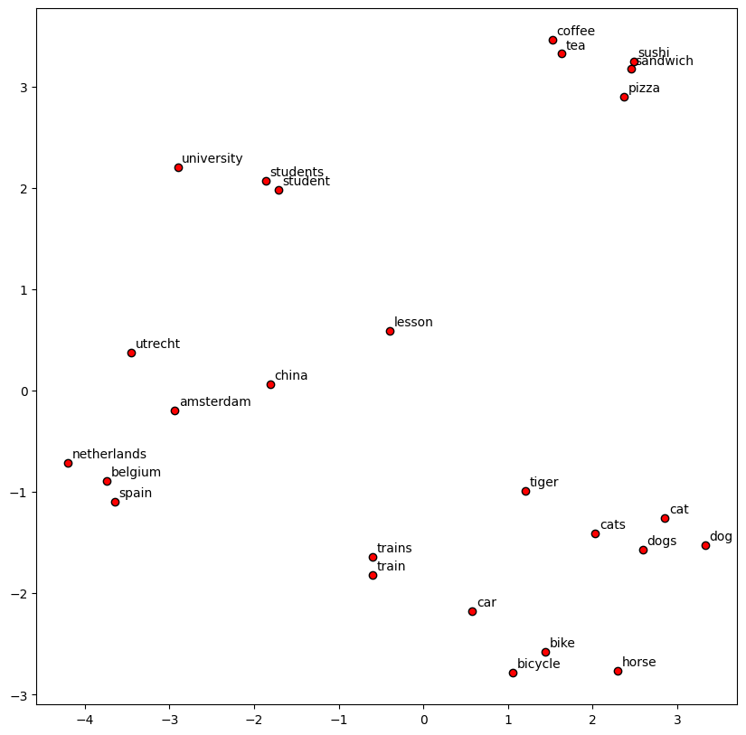

```python
display_scatterplot(wv,
                        ['dog', 'cat', 'dogs', 'cats', 'horse', 'tiger',
                         'university', 'lesson', 'student', 'students',
                         'netherlands', 'amsterdam', 'utrecht', 'belgium', 'spain', 'china',
                         'coffee', 'tea', 'pizza', 'sushi', 'sandwich',
                         'car', 'train', 'bike', 'bicycle', 'trains'])
```

**Question:** What do you notice in this plot?  
Do the distances between the words make sense? Any surprises?  
Feel free to add your own words!

# Biases

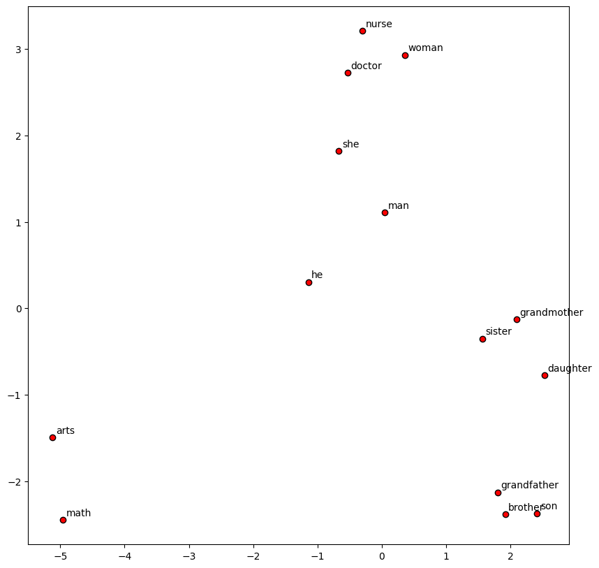

```python
display_scatterplot(wv,
                        ['he', 'she', 'sister',
                         'brother', 'man', 'woman',
                         'nurse', 'doctor',
                         'grandfather', 'grandmother',
                         'math', 'arts',
                         'daughter', 'son'])
```

```python
def calc_avg_similiarity(wv, attribute_words, target_word):
    score = 0

    for attribute_word in attribute_words:
            score += wv.similarity(attribute_word, target_word)

    return score/len(attribute_words)
```

```python
# set of attribute words
attribute_words_m = ['male', 'man', 'boy', 'brother', 'he', 'him', 'his', 'son']
attribute_words_f = ['female', 'woman', 'girl', 'sister', 'she',
                     'her', 'hers', 'daughter']
```

**Question:** Is *math* more associated with male or female words?

Compute the average cosine similarity between the target word and the set of attribute words.

```python
print("Avg. similarity with male words: %.3f" %
      calc_avg_similiarity(wv, attribute_words_m, 'math'))
print("Avg. similarity with female words: %.3f" %
      calc_avg_similiarity(wv, attribute_words_f, 'math'))
```

```
Avg. similarity with male words: 0.118
Avg. similarity with female words: 0.105
```

What about poetry?

```python
print("Avg. similarity with male words: %.3f" %
      calc_avg_similiarity(wv, attribute_words_m, 'poetry'))
print("Avg. similarity with female words: %.3f" %
      calc_avg_similiarity(wv, attribute_words_f, 'poetry'))
```

```
Avg. similarity with male words: 0.166
Avg. similarity with female words: 0.185
```

# Next Steps

Repeat this analysis but now with the GloVe model trained on Twitter data, e.g. `glove-twitter-50`.

- Which model obtains better performance on the word similarity task? (WordSim353)
- What other differences do you observe? (e.g., vocabulary, biases, etc.)

# FastText

*(Only if you have time, this can take a while — around 11 minutes)*

Load in a FastText model.

```python
wv_f = api.load('fasttext-wiki-news-subwords-300')
```

Usage is very similar to before. For example, we can calulcate the similarity between two words

```python
print(wv_f.similarity("dog", "dogs"))
```

[output not shown]

**Question:** How does this compare to the similarity scores you obtained with the other models you tried?